CENES · UPTC · martes 1 de septiembre de 2026

# Del asistente al sistema

Sesión 1 · Ideación — de la inquietud a la pregunta de investigación

0

Momento 0 · 6:00–6:40

## El proceso de investigación es un sistema, no una lista de tareas

Se muestra la máquina armada y funcionando. Después se desarma pieza por pieza.

Lámina 02 · Momento 0 · a dónde vamos

## El punto de llegada: seis sesiones, seis piezas

| Sesión | Fecha | Pieza que produce | Dónde aterriza en el paper |
| --- | --- | --- | --- |
| 01 | 1-sep | La pregunta + 3 objeciones respondidas | Introducción y motivación |
| 02 | 3-sep | Tabla de evidencia verificada contra DOI | Antecedentes |
| 03 | 5-sep | La base + el pipeline documentado | Datos y metodología |
| 04 | 8-sep | Lo que sobrevivió / lo que se descartó | Resultados y límites |
| 05 | 10-sep | La figura y la página | El exhibit central |
| 06 | 12-sep | — sin pieza nueva — | El engranaje |

El 12 de septiembre a las 12 **este documento existe y es de ustedes.**

Lámina 02b · quién les va a dictar esto

## Acerca de mí

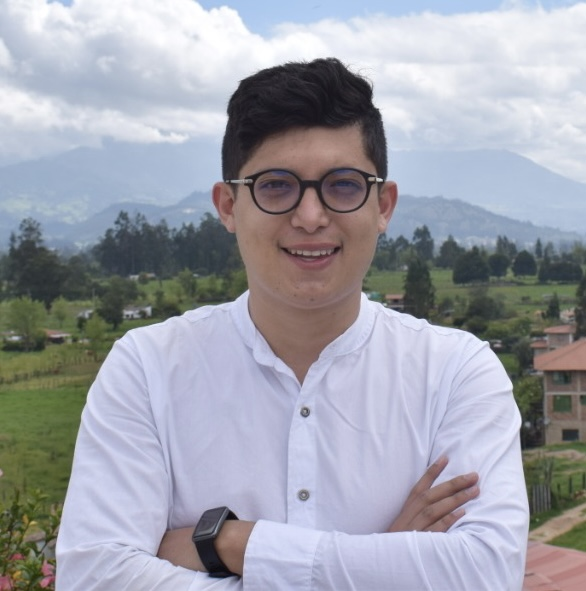

Alonso Ramírez Hernández

Jefe · Departamento de Investigaciones Económicas  
Cámara de Comercio de Cartagena

Formación

Economista de la **UPTC**. Maestría en Economía y estudios doctorales en Economía, **Universidad de los Andes**.

Experiencia

Departamentos de investigación del **Banco Mundial** y del **BID**. **DNP** y **DANE**. Hoy, el DIE de la Cámara de Comercio de Cartagena.

Áreas de investigación

Economía política · historia económica · métodos computacionales para datos.

Vengo de la UPTC. **Esto que van a aprender lo uso todos los días.**

Lámina 03 · la expectativa se acota aquí

## Y qué **no** es

lo que van a tener el 12-sep

Sí es

- Un working paper de **6 a 8 páginas**, uno por semillero.
- Una pregunta defendida, con evidencia verificada y una figura honesta.
- Un rastro que otro puede auditar.

lo que no van a tener

No es

- Un artículo listo para someter a una revista.
- Una revisión sistemática de la literatura.
- Un curso de programación.

La expectativa se acota aquí, **o se desborda sola.**

Lámina 04 · por qué ahora y no hace tres años

## Lo que cambió: el cuello de botella se movió

**Una sola persona sostiene hoy un flujo completo de investigación que hace tres años exigía un equipo y varios meses.**

Buscar, leer, limpiar, estimar, graficar y escribir dejaron de ser seis oficios distintos repartidos entre seis personas.

No porque la máquina piense mejor: porque el trabajo mecánico de cada paso —el que consumía las semanas— pasó a costar minutos.

hace tres años

Antes

Un equipo. Varios meses. Un asistente de investigación por etapa.

2026

Hoy

Una persona. Un flujo. El cuello de botella ya no es *hacer*: es **decidir qué vale la pena hacer**.

Y eso cambia cuál es la habilidad escasa. No es ejecutar: **es escoger.**

Lámina 05 · el dato

20%

usa agentes de código para investigar

De 1.260 científicos sociales cuantitativos encuestados entre febrero y marzo de 2026, uno de cada cinco ya trabaja con agentes. **El 81 % ha probado al menos un chatbot.**

Encuesta Anthropic a 1.260 científicos sociales cuantitativos, feb–mar 2026.

Lámina 06 · momento 0 · la brecha

## La brecha es de acceso, no de talento

Adopción de agentes de código, por disciplina

Economía

39%

Promedio

20%

Salud pública

6%

Educación

4%

2×

nombres masculinos

Adoptan al doble que los femeninos.

+40%

facultad top-25

Frente al resto de instituciones.

Encuesta Anthropic a 1.260 científicos sociales cuantitativos, feb–mar 2026.

Es de acceso, no de talento. Y el acceso, hoy, **cuesta cero pesos.**

Lámina 07 · bloque B · el mapa del proceso

## Seis casillas. **Hay herramienta para cada una.**

01Ideación

02Literatura

03Datos

04Análisis

05Escritura

06Comunicación

lo que vamos a recorrer

La tesis de este bloque

Para cada casilla del proceso existe hoy una herramienta madura, gratuita o casi, que hace en minutos lo que antes tomaba días.

lo que viene después

La trampa

Al final del bloque el mapa va a estar lleno y va a parecer que el problema está resuelto. **No lo está.**

Este mapa se queda fijo el resto del bloque. Vamos casilla por casilla.

Lámina 08 · casilla 01

## Ideación

01Ideación

02Literatura

03Datos

04Análisis

05Escritura

06Comunicación

asistente

Claude

Conversación larga con contexto. Sostiene un documento entero en la cabeza.

asistente

Gemini

Integrado a Drive y Colab. Cómodo si el material ya vive ahí.

asistente

ChatGPT

El más extendido. Sirve igual para esta casilla.

Para esta casilla **cualquiera de las tres sirve.** No es la elección que importa.

Lámina 09 · casilla 02

## Literatura

01Ideación

02Literatura

03Datos

04Análisis

05Escritura

06Comunicación

buscar

Semantic Scholar

Buscador académico. **Gratis y sin techo.**

mapear

ResearchRabbit

Mapa de citaciones. **Gratis y sin techo.**

sintetizar

Consensus · Elicit

Extracción de hallazgos de un cuerpo de artículos.

leer

NotebookLM

Preguntarle a los PDF que uno ya tiene, con cita al documento.

vigilar

Litmaps

Monitoreo continuo: avisa lo nuevo. Para una tesis larga.

ojo

El paso que falta

Ninguna de estas **verifica**. Eso es la casilla 06.

Lámina 10 · casillas 03 y 04

## Datos y análisis

01Ideación

02Literatura

03Datos

04Análisis

05Escritura

06Comunicación

google · gratis

Colab + Data Science Agent

Se sube un CSV. Se describe el objetivo **en español**. El agente escribe y corre el cuaderno entero.

Sin instalar nada en el computador. Corre en el navegador.

la lección

Lo que esto cambia

La barrera de entrada al análisis dejó de ser *saber programar*.

Pasó a ser **saber qué preguntarle a los datos** — y saber leer si la respuesta tiene sentido.

No se requiere programación previa en este curso. **Se requiere criterio.**

Lámina 11 · casilla 05

## Escritura y figuras

01Ideación

02Literatura

03Datos

04Análisis

05Escritura

06Comunicación

borrador

Asistentes

Para **iterar**: reescribir un párrafo, apretar una frase, discutir una estructura.

producto

Quarto · LaTeX

Para **producir**: un documento que se regenera solo cuando cambia el dato.

Estas láminas están hechas en Quarto.

la regla

La distinción

Iterar y producir **no son la misma herramienta**, y confundirlas cuesta días.

Lámina 12 · casilla 06

## Verificación

01Ideación

02Literatura

03Datos

04Análisis

05Escritura

06Comunicación

existencia

Crossref · DOI

¿Existe el artículo? El DOI resuelve o no resuelve. Binario, en dos segundos.

uso

scite

¿Y cómo lo citan? Apoyo, contraste o mención de paso.

ojo

El paso que casi nadie da

Es la casilla más barata del mapa y la que más se salta.

**El jueves abrimos el sobre sellado y lo hacemos en vivo.**

Lámina 13 · el mapa lleno

## Hay herramienta para cada casilla

01Ideación

02Literatura

03Datos

04Análisis

05Escritura

06Comunicación

Y sin embargo…

Lámina 14 · bloque C · el contraste

## Tareas sueltas: cada pieza es buena y nada se conecta

literatura → escritura

La referencia que halló Elicit

…**no llega al documento.** Se copia a mano, o se pierde.

análisis → documento

La figura que salió de Colab

…**no sabe de qué pregunta salió.** Es un PNG en la carpeta de descargas.

todo → auditoría

La cifra del párrafo tres

…**nadie puede rastrear de dónde salió.** Ni el propio autor, tres meses después.

Seis herramientas excelentes. **Cero conexiones entre ellas.**

Lámina 15 · la consecuencia, medida

## Producir más no es terminar más

+25%

proyectos arrancados

Los que usan agentes empiezan más cosas.

+50%

working papers

Y publican más documentos de trabajo.

0

más envíos a revistas

El sometimiento a revistas no se mueve.

Encuesta Anthropic a 1.260 científicos sociales cuantitativos, feb–mar 2026.

El embudo no se ensanchó al final: **se ensanchó al principio.**

Lámina 16 · la salida

## Sistema

lo que casi todos tienen

Una calculadora

Cada operación es correcta.

Ninguna se acuerda de la anterior.

Seis herramientas, seis resultados sueltos.

lo que vamos a montar

Una contabilidad

Carpetas **con función**.

Una **puerta única** a los datos.

Las decisiones **registradas**.

Un **rastro** que otro puede auditar.

Las mismas herramientas. **La diferencia está en la arquitectura, no en el catálogo.**

Bloque D · ~15 min · pantalla compartida

## El demo: un paper en quince minutos

1

El dominio

Lo que traigo yo: contratación pública, economía política, territorio. **Esto no me lo da la máquina.**

2

La intuición

Los municipios adjudican más a dedo en año electoral. Es una hipótesis, no un tema.

3

Valorarla

¿Ya está respondida? ¿Es medible? ¿Le cambia la decisión a alguien? **Aquí la máquina ayuda atacando.**

4

El hueco en la literatura

Qué se ha hecho, verificado contra DOI. Brasil sí; Colombia subnacional, poco.

5

Los datos

¿SECOP tiene la variable, el periodo, el cruce? **Y qué le falta.**

6

La metodología viable

Panel municipio-año y elecciones escalonadas: qué diseño aguanta, y con qué límites.

7

El esqueleto

Pregunta · hipótesis · antecedentes · datos · diseño · límites. **Un paper empezado.**

Ninguno de los siete lo inventó la máquina. **Los siete los hace un investigador.**

1

Momento 1 · 6:40–7:00

## Una pregunta floja no mejora con una IA mejor

El problema no es la herramienta: es la pregunta.

Lámina 17 · volvamos al principio

## Llega la convocatoria al correo. ¿Qué hace uno?

el caso de hoy

La convocatoria

CAF · economía urbana · marzo de 2026.

Un plazo, unas líneas temáticas, un formulario.

Es el caso real que va a atravesar las tres horas, cuatro veces.

lo que hacemos todos

El reflejo

Abrir el chat y escribir lo primero que se le ocurre a uno.

**Hagámoslo. En vivo, ahora.**

Lámina 18 · en vivo

## La pregunta floja

lo que se escribe en el chat, delante de la sala¿qué temas de investigación puedo proponer para una convocatoria  
de economía urbana?

el resultado

Lo que devuelve

Una lista correcta. Ordenada. Con subtítulos.

**Y completamente promedio.**

lo que falta

Lo que NO devuelve

Nada que dependa de *sus* datos, de *su* territorio, de *su* plazo. Porque no se lo dijimos.

Lámina 19 · el control

## La misma pregunta, en Google

buscador

Google

Resultados igual de genéricos: listados de temas, blogs, una convocatoria vieja.

asistente

El chat

Redacción mejor. **Contenido igual de vacío.**

No es que una sea mejor que la otra: **es que la pregunta no tiene nada adentro.**

Lámina 20 · por qué pasa

El promedio

de todo lo ya escrito

Sin contexto, la máquina devuelve el centro de la distribución de lo que existe. **Y el promedio no gana convocatorias ni sostiene una tesis.**

Lámina 21 · la evidencia · 1

## Stanford 2024: las ideas de la máquina salieron más novedosas

49

investigadores expertos

Escribieron ideas de investigación.

79

revisores a ciegas

Calificaron sin saber quién escribió qué.

qué hicieron

El montaje

Unos expertos escriben ideas. Un agente genera otras. Las califican **a ciegas**, mezcladas.

qué salió

El resultado

Las de la máquina puntúan **más alto en novedad**.

Y esa es la mala noticia — por ahora.

Si et al., Stanford 2024 · 49 investigadores expertos, 79 revisores a ciegas.

Esperen.

Lámina 23 · la evidencia · 2

## Stanford 2025: mandaron a ejecutarlas

43

investigadores

Ejecutaron las ideas de verdad.

100+

horas cada uno

No es una lectura: es trabajo real.

Stanford 2025 · ejecución de las ideas: 43 investigadores, 100+ horas cada uno.

Al evaluar los **resultados**, las ideas de la máquina caen mucho más — y en varias métricas **el ranking se voltea**.

Lámina 24 · la lección

## La novedad es barata. La factibilidad es cara.

la máquina

Gana en la idea

Cubrir el espacio de lo posible, rápido y sin apego.

**Ahí la máquina es mejor que uno.**

usted

Saber qué se puede sostener con los datos, el plazo y las manos que hay.

**Eso lo pone el investigador.**

Y esta lámina vuelve en el momento 3, **convertida en método.**

Actividad 1 · 5 min · el sobre sellado

## Háganle a su herramienta la pregunta floja sobre su propio tema

1

La pregunta floja

La que uno escribiría sin pensar. Se pega en la bitácora tal cual.

2

Cinco referencias

Autor, año, revista y **DOI**. Se pegan sin abrirlas.

el sobre sellado

La regla

**No las verifiquen.**

El jueves las abrimos juntos.

Doble función: queda el punto de comparación para el momento 2, y queda el material verificable para la sesión 2.

2

Momento 2 · 7:00–7:30

## Un buen prompt afina la idea — y aun así no basta

30 minutos. Se mejora el prompt hasta el techo, para poder ver dónde está el techo.

Lámina 25 · anatomía

## Las cinco partes de un prompt que sí sirve

01

Rol

Desde dónde habla.

02

Contexto

Lo que sabe de mi caso.

03

Tarea

Qué tiene que producir.

04

Formato

Con qué forma lo devuelve.

05

Prohibiciones

**Lo que NO debe hacer.**

La quinta es la que **nadie escribe** — y es la que más cambia el resultado.

Lámina 26 · para acordarse

## PARTS

P

Persona

Quién habla y a quién.

A

Aim

Para qué: el objetivo real.

R

Recipients

Quién va a leer el resultado.

T

Theme

El contenido y su contexto.

S

Structure

La forma de la salida.

No es un método: **es una lista para no olvidar nada** a las once de la noche.

Lámina 27 · en vivo, con el CAF

## La misma consulta, ahora con el contexto real

lo que se le pone adentro, esta vezTengo un panel de 111 actos normativos de PEMP (1993–2023) y 37 áreas  
protegidas, con 6 ciudades cuya fecha de tratamiento está confirmada.  
La convocatoria es de economía urbana. Soy un investigador solo y  
tengo un año.

Es el mismo modelo, la misma sesión y la misma pregunta de fondo. **Lo único que cambió fue lo que se le puso adentro.**

Lámina 28 · lo que devuelve ahora

## Direcciones específicas, con estrategia de identificación

pregunta floja

Antes

«Estudiar el impacto del desarrollo urbano en la calidad de vida.»

Correcto. Inútil.

con contexto

Ahora

Direcciones con **qué estimar**, **cómo identificar** y **qué datos hacen falta**.

La diferencia no fue el modelo: **fue lo que le puse adentro.**

Lámina 29 · pero

## Un prompt bueno produce un buen resultado suelto

falta 01

No escoge

Devuelve tres direcciones y ahí se acaba.

falta 02

No registra por qué

Ninguna razón de descarte queda escrita.

falta 03

Mañana no se acuerda

El chat se cierra y el criterio se pierde.

Por eso el momento 3 no enseña un prompt mejor: **enseña una secuencia.**

Actividad 2 · 15 min · ficha 1 del cuaderno

## Reescriban la pregunta floja como prompt

la parte que cuesta

Qué hacer con lo que devuelve

Escoger **una** formulación.

Descartar las otras dos **por escrito**.

Si las tres suenan igual de bien, la inquietud sigue vaga: **volver al papel**.

Prompt 1 · formular · modo HACESoy estudiante de [programa] en la UPTC. Mi inquietud de investigación  
es: «[una frase]».  
Conviértela en una pregunta de investigación con esta estructura: qué  
efecto de X sobre Y, en qué población, en qué territorio, con qué datos.  
Devuélveme tres formulaciones alternativas, de la más ambiciosa a la más  
viable en un semestre. Para cada una: qué dato haría falta y quién lo tiene.  
No me des temas nuevos. Trabaja sobre el mío.

Pausa.

Diez minutos. A las 7:40 arranca el momento 3.

3

Momento 3 · 7:40–8:35

## El brainstorming ordenado: una secuencia, no un prompt

55 minutos. Es el bloque que produce la casilla 01 del paper.

Lámina 30 · el giro

## Un prompt es un disparo. La ideación es un embudo.

el prompt

Un disparo

Se apunta, se dispara, sale algo.

Si falla, se vuelve a disparar.

No hay memoria entre disparos.

la secuencia

Un embudo

Entra ancho, sale angosto.

**Y tiene pasos que no se saltan.**

Cada paso deja algo escrito.

Cinco pasos. Los vemos uno por uno, **con el CAF real encima.**

Lámina 31 · paso 1

## Partir del activo

1

Partir del activo

No de «qué me interesa» sino de qué tengo ya.

2

Generar alternativas

Tres direcciones que cubran el espacio.

3

Criterios ANTES

Escritos antes de mirar las opciones.

4

Registrar el descarte

Por qué se rechazó lo demás, por escrito.

5

Recién ahí, ejecutar

Lo que sobrevivió al embudo.

el caso real

En el CAF

El activo era **un panel ya construido**: 111 actos normativos, 37 áreas protegidas, 6 ciudades con fecha de tratamiento.

la lección

Por qué es bueno

El activo **restringe** el espacio de preguntas.

Una restricción temprana no es una pérdida: es lo que hace la pregunta contestable.

Lámina 32 · paso 2

## Generar alternativas

1

Partir del activo

No de «qué me interesa» sino de qué tengo ya.

2

Generar alternativas

Tres direcciones que cubran el espacio.

3

Criterios ANTES

Escritos antes de mirar las opciones.

4

Registrar el descarte

Por qué se rechazó lo demás, por escrito.

5

Recién ahí, ejecutar

Lo que sobrevivió al embudo.

el formato

Tres direcciones

Cada una con **qué estimar**, **identificación**, **datos** y **limitación**.

por qué aquí

Aquí sí sirve la máquina

El trabajo de este paso es **cubrir el espacio**, no elegir. Es exactamente en lo que gana — la lámina 24.

Lámina 33 · paso 3

## Los criterios se escriben antes

1

Partir del activo

No de «qué me interesa» sino de qué tengo ya.

2

Generar alternativas

Tres direcciones que cubran el espacio.

3

Criterios ANTES

Escritos antes de mirar las opciones.

4

Registrar el descarte

Por qué se rechazó lo demás, por escrito.

5

Recién ahí, ejecutar

Lo que sobrevivió al embudo.

escritos en marzo

Los cinco reales del CAF

- Ajuste a la convocatoria
- Identificación causal creíble
- Factibilidad de datos en el plazo
- Novedad
- **Factibilidad para una sola persona**

Si se escriben después, **uno no decide: justifica.**

Lámina 34 · paso 4

## Registrar el descarte

1

Partir del activo

No de «qué me interesa» sino de qué tengo ya.

2

Generar alternativas

Tres direcciones que cubran el espacio.

3

Criterios ANTES

Escritos antes de mirar las opciones.

4

Registrar el descarte

Por qué se rechazó lo demás, por escrito.

5

Recién ahí, ejecutar

Lo que sobrevivió al embudo.

el caso real

En el CAF

La idea 3 quedó anotada como **«mejor para otro paper»**.

la lección

Para qué sirve

Un descarte con razón escrita **no se vuelve a discutir en tres meses**.

Y si vuelve, vuelve con un argumento nuevo, no con la misma duda.

Lámina 35 · paso 5

## Recién ahí, ejecutar

1

Partir del activo

No de «qué me interesa» sino de qué tengo ya.

2

Generar alternativas

Tres direcciones que cubran el espacio.

3

Criterios ANTES

Escritos antes de mirar las opciones.

4

Registrar el descarte

Por qué se rechazó lo demás, por escrito.

5

Recién ahí, ejecutar

Lo que sobrevivió al embudo.

3

direcciones exploradas

Salieron del paso 2.

2

ejecutadas

Sobrevivieron al embudo.

la prueba

Dónde se ve el embudo

**En las carpetas** — no en la memoria de nadie.

La máquina cubre el espacio de ideas.  
El investigador escoge dentro de él.

Es la lámina 24, ahora convertida en método.

Actividad 3 · 20 min · el interrogatorio · ficha 2

## Pídanle a la máquina que tumbe su pregunta

la parte que cuesta

Qué hacer con lo que devuelve

Responder las tres objeciones **por escrito**.

Una objeción sin respuesta escrita **no cuenta**.

Esas respuestas son el borrador de la introducción: la casilla 01.

Va a empezar con «excelente pregunta» **aunque el prompt lo prohíba**. Se muestra en pantalla y se nombra: hay que **leer** lo que devuelve, no recibirlo.

Prompt 2 · interrogar · modo CRITICAEsta es mi pregunta de investigación: «[pregunta]».  
Actúa como el evaluador más exigente de mi comité. Dame las tres  
razones más fuertes por las que esta pregunta no vale la pena  
investigarse: porque ya está respondida, porque no es medible con  
datos accesibles, o porque la respuesta no le cambia la decisión  
a nadie.  
Sé concreto y duro. No me elogies la pregunta y no propongas  
alternativas. Solo las objeciones.  
Para cada una, dime qué tendría que mostrarte yo para tumbarla.

Actividad 4 · 20 min · rotación humana

## Ahora sin IA: ataquen la pregunta del compañero

20 minutos

La mecánica

Intercambian preguntas.

Cinco minutos, por escrito, sin máquina.

Después comparan las dos listas de objeciones.

la razón de la actividad

El descubrimiento que debe ocurrir

Son **distintas**.

La máquina es fuerte en lo metodológico genérico —endogeneidad, selección, validez externa— y **ciega en lo local**.

«Eso ya lo hizo el grupo de la UPTC en 2023» · «en Boyacá esa variable no se mide» · «esa base la administra una entidad que no la entrega»

4

Momento 4 · 8:35–8:55

## Cómo esto queda dentro de un sistema

20 minutos. La misma conversación con la máquina — pero la idea no vivió en un chat.

Lámina 37 · la carpeta real

## La idea no vivió en un chat: vivió en archivos

1

00_Call_Context

La convocatoria y su resumen.

2

01_Idea_Exploration

Las tres ideas y el brainstorm.

3

02_Idea_Selection

El decision log y la idea escogida.

4

03_Execution

Las dos líneas que sobrevivieron.

5

04_Submission

Lo que se mandó.

Es la carpeta del CAF, de marzo. **Se proyecta tal cual.**

Lámina 38 · qué hace «sistema»

## Tres cosas. Ni una más.

01

Carpetas con función

Cada una responde una pregunta del proceso, no un tipo de archivo.

02

Una decisión registrada

Qué se escogió y por qué se descartó el resto.

03

Un rastro auditable

Que otra persona pueda seguir de la cifra al dato crudo.

Nada más y nada menos. **No hace falta software nuevo para tener las tres.**

Lámina 39 · la confesión

## En ese proyecto el paso 4 quedó a medias

02_Idea_Selection/decision_log.md · marzo de 2026## Criteria  
1. Fit with the call  
2. Credible identification  
3. Data feasibility  
4. Novelty  
5. Feasible for one person  
## Selected Idea  
## Reasons for Rejecting Others

bien

Lo que sí quedó

Los cinco criterios, escritos **antes**. El paso 3 se hizo.

mal

Lo que no

La casilla del descarte sigue con el comentario puesto. **El paso 4 se saltó.**

Lámina 40 · por eso

20%

de la nota es la bitácora

No porque el docente sea ordenado, sino porque **se saltó el paso y sabe lo que cuesta**.

Lámina 41 · por qué la ideación manda

## No es una etapa que se pasa: es la que restringe a todas las demás

el buen caso

Si la pregunta está bien puesta

Las otras cinco sesiones tienen a dónde ir.

Cada pieza aterriza en una casilla del paper.

el mal caso

Si está mal puesta

Las otras cinco sesiones se convierten en **trabajo bien hecho sobre algo que no importa**.

Por eso la sesión 1 es la más larga y la más incómoda.

El jueves a las 6  
abrimos el sobre sellado.

Traigan las cinco referencias sin tocar. Ninguna verificada.

Cierre · 8:55–9:00

## Se marca la casilla 01

| Sesión | Fecha | Pieza que produce | Estado |
| --- | --- | --- | --- |
| 01 | 1-sep | La pregunta + 3 objeciones respondidas | ✔ llena |
| 02 | 3-sep | Tabla de evidencia verificada contra DOI | — |
| 03 | 5-sep | La base + el pipeline documentado | — |
| 04 | 8-sep | Lo que sobrevivió / lo que se descartó | — |
| 05 | 10-sep | La figura y la página | — |
| 06 | 12-sep | — sin pieza nueva — | — |

Primera vez que ven el engranaje moverse, **a las tres horas de haber empezado.**

Cierre · la entrega

## La bitácora se llena en clase, no después

| Qué pedí | Qué devolvió | Qué corregí | Por qué |
| --- | --- | --- | --- |
| … | … | … | … |
| … | … | … | … |

Cuatro columnas. 20 % de la nota.

seis piezas

Entrega al repositorio, antes del jueves 6:00 p.m.

- La pregunta formulada
- Dos hipótesis alternativas
- Las tres objeciones **respondidas**
- La objeción del compañero
- Estrategia preliminar de datos
- **El sobre sellado, sin tocar**

Tarea adicional: **ninguna**. La entrega es la tarea.